# PSY 5790: Applied Univariate and Bivariate/Bivariable Statistics

Week 11 - Chi-Square Demo

Christopher J. Schmank, PhD

2026-04-23

```r
library(tidyverse)
library(psych)
library(jmv)
library(infer)
```

**Load in required data**

```r
dat <- read.csv("Salary-1.csv")
glimpse(dat)
```

```
## Rows: 4,642
## Columns: 3
## $ sex   <int> 1, 1, 1, 1, 2, 2, 1, 2, 2, 2, 2, 2, 1, 1, 1, 1, 2, 1, 1, 2, 1, 2…
## $ rank  <int> 1, 1, 1, 1, 1, 1, 2, 2, 2, 2, 2, 2, 2, 2, 1, 1, 2, 2, 2, 3, 3, 3…
## $ level <int> 1, 1, 1, 1, 1, 1, 1, 1, 1, 1, 1, 1, 1, 1, 1, 1, 1, 1, 1, 1, 1, 1…
```

```r
head(dat)
```

```
##   sex rank level
## 1   1    1     1
## 2   1    1     1
## 3   1    1     1
## 4   1    1     1
## 5   2    1     1
## 6   2    1     1
```

```r
set.seed(13)
datA <- dat %>%
  rep_sample_n(size = 1000,
               replace = TRUE,
               reps = 1)
```

**Data Explanation**

The data ($n = 1000$) comes from the faculty salary example ($N = 4642$)

There were three variables:

`sex` (sex of professor): 1 = male, 2 = female

`rank` (rank of professor): 1 = full professor, 2 = associate professor, 3 = assistant professor, 4 = instructor

`level` (type of program that professor teaches in): 1 = doctoral program, 2 = masters program

**Look at `observed frequencies` for each variable**

```r
sex <- table(datA$sex)
sex
```

```
##
##   1   2
## 593 407
```

```r
rank <- table(datA$rank)
rank
```

```
##
##   1   2   3   4
## 421 284 278  17
```

```r
level <- table(datA$level)
level
```

```
##
##   1   2
## 815 185
```

*Note*: This output would be easier to interpret if we `relabeled` the various levels of our categorical variables

**Re-label levels of categorical variables**

```r
# These re-write the variables in `dat` as `factors` and codes the output based on the provided labels
datA$sex <- factor(datA$sex,
                   levels = c(1,2),
                   labels = c("Male", "Female"))

datA$rank <- factor(datA$rank,
                    levels = c(1,2,3,4),
                    labels = c("Full", "Associate", "Assistant", "Instructor"))

datA$level <- factor(datA$level,
                     levels = c(1,2),
                     labels = c("Doctorate", "Masters"))
```

**Reassess `observed frequencies`**

```r
sex <- table(datA$sex)
sex
```

```
##
##   Male Female
##    593    407
```

```r
rank <- table(datA$rank)
rank
```

```
##
##       Full  Associate  Assistant Instructor
##        421        284        278         17
```

```r
level <- table(datA$level)
level
```

```
##
## Doctorate   Masters
##       815       185
```

**Chi-Square ($\chi^2$) `Goodness-of-Fit` Test**

Determines how well a categorical distribution “fits” an expected distribution

**Research Question**: Were there equal representations amongst our categorical variable levels?

**Null hypothesis**: $H_0 = \text{Equal Proportions Amongst Groups}$

**Alternative hypothesis**: $H_A = \text{Unequal Proportions Amongst Groups}$

$$\chi^2 = \Sigma((Observed -
Expected)^2/Expected) \\ df = \text{# categories - 1}$$

For these three variables **unless otherwise specified** the `expected frequencies` are:

`sex` (sex of professor): male 50% — $n = 500$, female 50% — $n = 500$

`rank` (rank of professor): full professor 25% — $n = 250$, associate professor 25% — $n = 250$, assistant professor 25% — $n = 250$, instructor 25% — $n = 250$

`level` (type of program that professor teaches in): doctoral program 50% — $n = 500$, masters program 50% — $n = 500$

**Specific Example 1**

**Research Question**: Were there the same proportion of `doctoral` and `masters program` professors?

**Null hypothesis**: $H_0 = \text{Equal Proportions Between Doctoral and Master}$ — Program level will be equally distributed across our sample of $n = 1000$ participants, $p_{doctoral} = p_{masters}$

**Alternative hypothesis**: $H_A = \text{Unequal Proportions}$ — Program level will be unequally distributed across our sample of $n = 1000$ participants, $p_{doctoral} \neq p_{masters}$

```r
propTestN(data = datA,
          var = 'level',
          expected = TRUE,
          ratio = c(1,1))
```

```
##
##  PROPORTION TEST (N OUTCOMES)
##
##  Proportions - level
##  ───────────────────────────────────────────────────
##    Level                    Count       Proportion
##  ───────────────────────────────────────────────────
##    Doctorate    Observed         815     0.8150000
##                 Expected    500.0000     0.5000000
##
##    Masters      Observed         185     0.1850000
##                 Expected    500.0000     0.5000000
##  ───────────────────────────────────────────────────
##
##
##  χ² Goodness of Fit
##  ────────────────────────────────
##    χ²          df    p
##  ────────────────────────────────
##    396.9000     1    < .0000001
##  ────────────────────────────────
```

**Write Up/Interpretation**:

A chi-square ($\chi^2$) goodness of fit test was performed to evaluate whether the distribution of professors was equivalent across `doctoral` and `masters` programs. The distribution of professors was different between `doctoral` and `masters` programs, $\chi^2(1, N = 1000) = 396.90, p < .001$. Observed and expected frequencies for each condition are presented in Table X.

**Specific Example 1B**

**Research Question**: Was the proportion of `doctoral` to `masters program` professors .80/.20?

**Null hypothesis**: $H_0 = \text{Proportion Between Doctoral and Master Equivalent to .80/.20}$ — Program level will be distributed with 80% Doctoral and 20% Masters across our sample of $n = 1000$ participants, $p_{doctoral} = .80; p_{masters} = .20$

**Alternative hypothesis**: $H_A = \text{Different Proportional Breakdown}$ — Program level will not be distributed with 80% Doctoral and 20% Masters across our sample of $n = 1000$ participants, $p_{doctoral} \neq .80; p_{masters} \neq .20$

```r
propTestN(data = datA,
          var = 'level',
          expected = TRUE,
          ratio = c(.80,.20))
```

```
##
##  PROPORTION TEST (N OUTCOMES)
##
##  Proportions - level
##  ───────────────────────────────────────────────────
##    Level                    Count       Proportion
##  ───────────────────────────────────────────────────
##    Doctorate    Observed         815     0.8150000
##                 Expected    800.0000     0.8000000
##
##    Masters      Observed         185     0.1850000
##                 Expected    200.0000     0.2000000
##  ───────────────────────────────────────────────────
##
##
##  χ² Goodness of Fit
##  ───────────────────────────────
##    χ²          df    p
##  ───────────────────────────────
##    1.406250     1    0.2356799
##  ───────────────────────────────
```

**Write Up/Interpretation**:

A chi-square ($\chi^2$) goodness of fit test was performed to evaluate whether the distribution of professors across `doctoral` and `masters` programs was 80% doctoral/20% masters, respectively. The distribution of professors across `doctoral` and `masters` programs was not different than expected (80%/20%), $\chi^2(1, N = 1000) = 1.41, p = .24$. Observed and expected frequencies for each condition are presented in Table X.

**Specific Example 2**

**Research Question**: Were there the same proportion of `male` and `female` professors?

**Null hypothesis**: $H_0 = \text{Equal Proportions Between Female and Male Professors}$ — Gender will be equally distributed across our $n = 1000$ sample, $p_{male} = p_{female}$

**Alternative hypothesis**: $H_A = \text{Unequal Proportions}$ — Gender will be unequally distributed across our $n = 1000$ sample, $p_{male} \neq p_{female}$

```r
propTestN(data = datA,
               var = 'sex',
               expected = TRUE,
               ratio = c(1,1))
```

```
##
##  PROPORTION TEST (N OUTCOMES)
##
##  Proportions - sex
##  ────────────────────────────────────────────────
##    Level                 Count       Proportion
##  ────────────────────────────────────────────────
##    Male      Observed         593     0.5930000
##              Expected    500.0000     0.5000000
##
##    Female    Observed         407     0.4070000
##              Expected    500.0000     0.5000000
##  ────────────────────────────────────────────────
##
##
##  χ² Goodness of Fit
##  ────────────────────────────────
##    χ²          df    p
##  ────────────────────────────────
##    34.59600     1    < .0000001
##  ────────────────────────────────
```

**Write Up/Interpretation**:

A chi-square ($\chi^2$) goodness of fit test was performed to evaluate whether the distribution of `gender` was equivalent across `males` and `female` professors. The distribution of `gender` was different between `male` and `female` professors, $\chi^2(1, N = 1000) = 34.60, p < .001$. Observed and expected frequencies for each condition are presented in Table X.

**Specific Example 3**

**Research Question**: Were there the equal proportions of professor `rank`?

**Null hypothesis**: $H_0 = \text{Equal Proportions Amongst Rank Levels}$ — Professor rank will be equally distributed across our $n = 1000$ sample, $p_{Full} = p_{Associate} = p_{Assistant} = p_{Instructor}$

**Alternative hypothesis**: $H_A = \text{Unequal Proportions}$ — Professor rank will not be equally distributed across our $n = 1000$ sample, $p_{Full} \neq p_{Associate} \neq p_{Assistant} \neq p_{Instructor}$

```r
propTestN(data = datA,
               var = 'rank',
               expected = TRUE,
               ratio = c(1,1,1,1))
```

```
##
##  PROPORTION TEST (N OUTCOMES)
##
##  Proportions - rank
##  ────────────────────────────────────────────────────
##    Level                     Count       Proportion
##  ────────────────────────────────────────────────────
##    Full          Observed         421    0.42100000
##                  Expected    250.0000     0.2500000
##
##    Associate     Observed         284    0.28400000
##                  Expected    250.0000     0.2500000
##
##    Assistant     Observed         278    0.27800000
##                  Expected    250.0000     0.2500000
##
##    Instructor    Observed          17    0.01700000
##                  Expected    250.0000     0.2500000
##  ────────────────────────────────────────────────────
##
##
##  χ² Goodness of Fit
##  ────────────────────────────────
##    χ²          df    p
##  ────────────────────────────────
##    341.8800     3    < .0000001
##  ────────────────────────────────
```

**Write Up/Interpretation**:

A chi-square ($\chi^2$) goodness of fit test was performed to evaluate whether the distribution of the `rank` of sampled professors was equivalent across `Full Professor`, `Associate Professor`, `Assistant Professor` and `Instructors`. The distribution of `rank` was different among the levels of professor `rank`, $\chi^2(3, N = 1000) = 341.88, p < .001$. Observed and expected frequencies for each condition are presented in Table X.

**Specific Example 3B**

**Research Question**: Do the `observed frequencies` of our sampled `rank` variable differ from the `expected frequencies` of 42% Full Professors, 28% Associate Professors, 28% Assistant Professors, and 2% Instructors?

**Null hypothesis**: $H_0 = \text{Observed Proportions Amongst Rank Levels Approximate Expected}$ — Professor rank will be distributed with 42% Full, 28% Associate, 28% Assistant, and 2% Instructors across our sample of $n = 1000$ participants, $p_{Full} = .42; p_{Associate} = .28; p_{Assistant} = .28; p_{Instructor} = .02$

**Alternative hypothesis**: $H_A = \text{Observed Proportions Different Than Expected}$ — Professor rank will not be distributed with 42% Full, 28% Associate, 28% Assistant, and 2% Instructors across our sample of $n = 1000$ participants, $p_{Full} \neq .42; p_{Associate} \neq .28; p_{Assistant} \neq .28; p_{Instructor} \neq .02$

```r
propTestN(data = datA,
          var = 'rank',
          expected = TRUE,
          ratio = c(.42, .28, .28, .02))
```

```
##
##  PROPORTION TEST (N OUTCOMES)
##
##  Proportions - rank
##  ─────────────────────────────────────────────────────
##    Level                     Count        Proportion
##  ─────────────────────────────────────────────────────
##    Full          Observed          421    0.42100000
##                  Expected    420.00000    0.42000000
##
##    Associate     Observed          284    0.28400000
##                  Expected    280.00000    0.28000000
##
##    Assistant     Observed          278    0.27800000
##                  Expected    280.00000    0.28000000
##
##    Instructor    Observed           17    0.01700000
##                  Expected     20.00000    0.02000000
##  ─────────────────────────────────────────────────────
##
##
##  χ² Goodness of Fit
##  ────────────────────────────────
##    χ²           df    p
##  ────────────────────────────────
##    0.5238095     3    0.9136303
##  ────────────────────────────────
```

**Write Up/Interpretation**:

A chi-square ($\chi^2$) goodness of fit test was performed to evaluate whether the distribution of professors across `Full`, `Associate`, `Assistant`, and `Instructor` ranks was 42% `Full`, 28% `Associate`, 28% `Assistant` and 2% `Instructor`. The distribution of `rank` was not different than expected, $\chi^2(3, N = 1000) = 0.52, p = .91$. Observed and expected frequencies for each condition are presented in Table X.

**Chi-Square ($\chi^2$) Test of Independence**

Determines whether two categorical variables are associated

**Research Question**: Was there a relationship between two categorical variables?

**Null hypothesis**: $H_0 = \text{Variables Not Related}$

**Alternative hypothesis**: $H_A = \text{Variables Related}$

$$\chi^2 = \Sigma((Observed -
Expected)^2/Expected) \\ Expected = (n_{Row}/N_{Total}) \cdot n_{Column}
\\ df = \text{# rows - 1} \cdot \text{# categories - 1}$$

**Specific Example 1**

**Research Question**: Was there a relationship between `sex` and `level`?

**Null hypothesis**: $H_0 = \text{No Association Between Sex and Level}$ — There was no association between gender and program level in our $n = 1000$ sample

**Alternative hypothesis**: $H_A = \text{Association}$— There was some association between gender and program level in our $n = 1000$ sample

```r
contTables(dat = datA,
           rows = 'sex',
           cols = 'level',
           exp = TRUE,
           phiCra = TRUE)
```

```
##
##  CONTINGENCY TABLES
##
##  Contingency Tables
##  ─────────────────────────────────────────────────────────────
##    sex                   Doctorate    Masters      Total
##  ─────────────────────────────────────────────────────────────
##    Male      Observed          485          108          593
##              Expected     483.2950    109.70500     593.0000
##
##    Female    Observed          330           77          407
##              Expected     331.7050     75.29500     407.0000
##
##    Total     Observed          815          185         1000
##              Expected     815.0000    185.00000    1000.0000
##  ─────────────────────────────────────────────────────────────
##
##
##  χ² Tests
##  ───────────────────────────────────────
##          Value         df    p
##  ───────────────────────────────────────
##    χ²    0.07988594     1    0.7774520
##    N           1000
##  ───────────────────────────────────────
##
##
##  Nominal
##  ──────────────────────────────────
##                       Value
##  ──────────────────────────────────
##    Phi-coefficient    0.008937893
##    Cramer's V         0.008937893
##  ──────────────────────────────────
```

**Write Up/Interpretation**: A chi-square ($\chi^2$) test of independence was performed to evaluate the relationship between `gender` and `program level` of professor. These variables were not associated, $\chi^2(1, N = 1000) = 0.08, p = .78, \phi = .01$. Neither `males` nor `females` were more likely to be employed in the `doctoral` or `masters` programs than expected.

**Specific Example 2**

**Research Question**: Was there a relationship between `sex` and `rank`?

**Null hypothesis**: $H_0 = \text{No Association Between Sex and Rank}$ — There was no association between gender and professor rank in our $n = 1000$ sample

**Alternative hypothesis**: $H_A = \text{Association}$ — There was some association between gender and professor rank in our $n = 1000$ sample

```r
contTables(dat = datA,
           rows = 'sex',
           cols = 'rank',
           exp = TRUE,
           phiCra = TRUE)
```

```
##
##  CONTINGENCY TABLES
##
##  Contingency Tables
##  ───────────────────────────────────────────────────────────────────────────────────────
##    sex                   Full        Associate    Assistant    Instructor    Total
##  ───────────────────────────────────────────────────────────────────────────────────────
##    Male      Observed         299          148          137             9          593
##              Expected    249.6530     168.4120     164.8540     10.081000     593.0000
##
##    Female    Observed         122          136          141             8          407
##              Expected    171.3470     115.5880     113.1460      6.919000     407.0000
##
##    Total     Observed         421          284          278            17         1000
##              Expected    421.0000     284.0000     278.0000     17.000000    1000.0000
##  ───────────────────────────────────────────────────────────────────────────────────────
##
##
##  χ² Tests
##  ──────────────────────────────────────
##          Value       df    p
##  ──────────────────────────────────────
##    χ²    41.89241     3    < .0000001
##    N         1000
##  ──────────────────────────────────────
##
##
##  Nominal
##  ────────────────────────────────
##                       Value
##  ────────────────────────────────
##    Phi-coefficient          NaN
##    Cramer's V         0.2046763
##  ────────────────────────────────
```

*Note*: Can determine which shared levels of the categorical variables are “driving” the $\chi^2$ statistic — look at difference of `observed` and `expected`, i.e., more extreme `differences` imply larger additions to the statistic!

**Specific Example 3**

**Research Question**: Was there a relationship between `level` and `rank`?

**Null hypothesis**: $H_0 = \text{No Association Between Level and Rank}$ — There was no association between program level and professor rank in our $n = 1000$ sample

**Alternative hypothesis**: $H_A = \text{Association}$ — There was some association between program level and professor rank in our $n = 1000$ sample

```r
contTables(dat = datA,
           rows = 'level',
           cols = 'rank',
           exp = TRUE,
           phiCra = TRUE)
```

```
##
##  CONTINGENCY TABLES
##
##  Contingency Tables
##  ───────────────────────────────────────────────────────────────────────────────────────────
##    level                    Full         Associate    Assistant    Instructor    Total
##  ───────────────────────────────────────────────────────────────────────────────────────────
##    Doctorate    Observed          351          232          221            11          815
##                 Expected    343.11500    231.46000    226.57000     13.855000     815.0000
##
##    Masters      Observed           70           52           57             6          185
##                 Expected     77.88500     52.54000     51.43000      3.145000     185.0000
##
##    Total        Observed          421          284          278            17         1000
##                 Expected    421.00000    284.00000    278.00000     17.000000    1000.0000
##  ───────────────────────────────────────────────────────────────────────────────────────────
##
##
##  χ² Tests
##  ─────────────────────────────────────
##          Value       df    p
##  ─────────────────────────────────────
##    χ²    4.906510     3    0.1787723
##    N         1000
##  ─────────────────────────────────────
##
##
##  Nominal
##  ─────────────────────────────────
##                       Value
##  ─────────────────────────────────
##    Phi-coefficient           NaN
##    Cramer's V         0.07004648
##  ─────────────────────────────────
```

**Write Up/Interpretation**: A chi-square ($\chi^2$) test of independence was performed to evaluate the relationship between `program level` and `professor rank`. These variables were not associated, $\chi^2(3, N = 1000) = 4.91, p = .18, \text{Cramer's V} = .07$. `Cramer's V` values of this magnitude are considered weak as an effect size measure of association between `program level` and `rank`. There was no association among graduate program and professor rank in this sample of data.

**What about the `infer` pipeline?**

**Standardized One Proportion Test** — Similar to $\chi^2$ GoF for Single Categorical Variable (2 levels)

```r
set.seed(13)
# Calculate Standardized Proportion Difference (p_hat) for Gender
p_hat<- datA %>%
  specify(response = sex, success = "Male") %>%
  hypothesize(null = "point", p = .5) %>%
  calculate(stat = "z")
p_hat
```

```
## Response: sex (factor)
## Null Hypothesis: point
## # A tibble: 1 × 1
##    stat
##   <dbl>
## 1  5.88
```

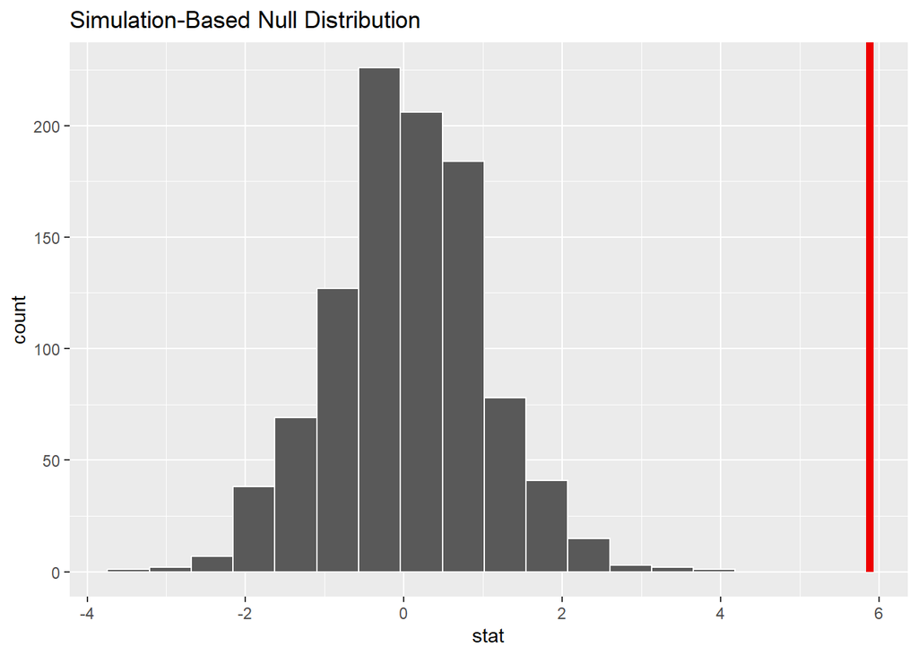

```r
# Generate Null Distribution for Visualization
null_dist_P <- datA %>%
  specify(response = sex, success = "Male") %>%
  hypothesize(null = "point", p = .5) %>%
  generate(reps = 1000, type ="draw") %>%
  calculate(stat = "z")
# `type = "draw"` is ONLY used for this chi-square GoF test

# Create Visualization with Observed value and larger highlighted
null_dist_P %>%
  visualize() +
  shade_p_value(obs_stat = p_hat, direction="greater")
```

```r
# Call for p-value associated with standardized proportion test
null_dist_P %>%
  get_p_value(obs_stat = p_hat, direction="greater")
```

```
## # A tibble: 1 × 1
##   p_value
##     <dbl>
## 1       0
```

```r
set.seed(13)
# Calculate Standardized Proportion Difference (p_hat2) for Level
p_hat2<- datA %>%
  specify(response = level, success = "Doctorate") %>%
  hypothesize(null = "point", p = .8) %>%
  calculate(stat = "z")
p_hat2
```

```
## Response: level (factor)
## Null Hypothesis: point
## # A tibble: 1 × 1
##    stat
##   <dbl>
## 1  1.19
```

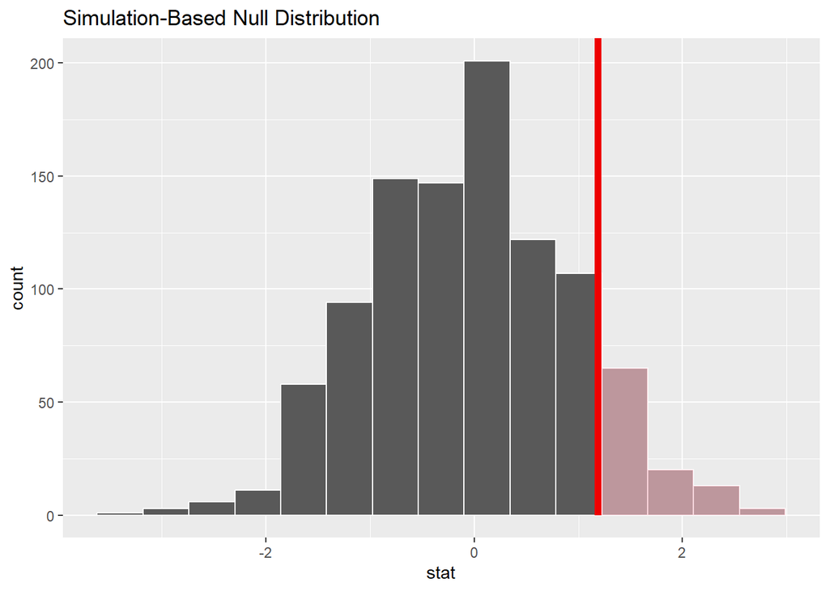

```r
# Generate Null Distribution for Visualization
null_dist_P2 <- datA %>%
  specify(response = level, success = "Doctorate") %>%
  hypothesize(null = "point", p = .8) %>%
  generate(reps = 1000, type ="draw") %>%
  calculate(stat = "z")

# Create Visualization with Observed value and larger highlighted
null_dist_P2 %>%
  visualize() +
  shade_p_value(obs_stat = p_hat2, direction="greater")
```

```r
# Call for p-value associated with standardized proportion test
null_dist_P2 %>%
  get_p_value(obs_stat = p_hat2, direction="greater")
```

```
## # A tibble: 1 × 1
##   p_value
##     <dbl>
## 1   0.114
```

**Standardized Difference in Proportion Test** — Similar to $\chi^2$ test of independence for two categorical variables (2 levels)

```r
set.seed(13)
# Calculate Standardized Difference in Proportion Test (z_hat) in Level across Sex
z_hat<- datA %>%
  specify(response = level, explanatory = sex, success = "Doctorate") %>%
  hypothesize(null = "independence") %>%
  calculate(stat = "z", order = c("Male","Female"))
z_hat
```

```
## Response: level (factor)
## Explanatory: sex (factor)
## Null Hypothesis: independence
## # A tibble: 1 × 1
##    stat
##   <dbl>
## 1 0.283
```

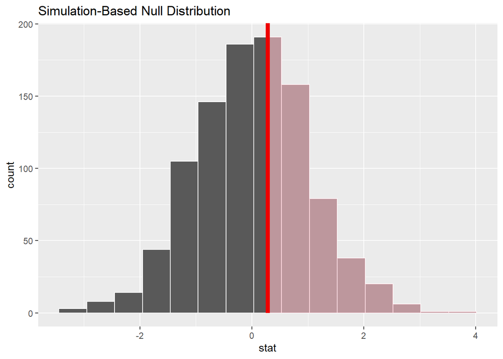

```r
# Generate Null Distribution for Visualization
null_dist_Z <- datA %>%
  specify(level ~ sex, success = "Doctorate") %>%
  hypothesize(null = "independence") %>%
  generate(reps = 1000, type = "permute") %>%
  calculate(stat = "z", order = c("Male", "Female"))

# Create Visualization with Observed value and larger highlighted
null_dist_Z %>%
  visualize() +
  shade_p_value(obs_stat = z_hat, direction="greater")
```

```r
# Call for p-value associated with standardized proportion difference test
null_dist_Z %>%
  get_p_value(obs_stat = z_hat, direction="greater")
```

```
## # A tibble: 1 × 1
##   p_value
##     <dbl>
## 1   0.417
```

**Comparing Chi-square values from `jmv` with `infer` categorical variable analyses**

```r
#Chi-square GoF Test on Gender:
chi_sq <- 34.59600
p_hat*p_hat
```

```
##     stat
## 1 34.596
```

```r
#Chi-square GoF Test on Level(p = .80):
chi_sq2 <- 1.406250
p_hat2*p_hat2
```

```
##      stat
## 1 1.40625
```

```r
#Chi-square Test of Independence (Gender x Level):
chi_sq3 <- 0.07988594
z_hat*z_hat
```

```
##         stat
## 1 0.07988594
```

**Can directly (re)conduct chi-square GoF test with categorical variables (>2 levels)**

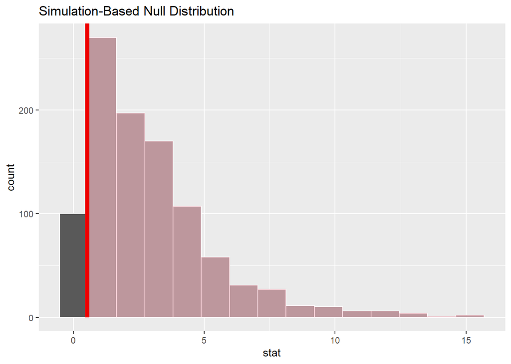

```r
set.seed(13)
# Calculate Chi-square GoF test using infer
chi_sq <- datA %>%
  specify(response = rank) %>%
  hypothesize(null = "point",
              p = c("Full" = .42,
                    "Associate" = .28,
                    "Assistant" = .28,
                    "Instructor" = .02)) %>%
  calculate(stat = "Chisq")

# Generate Null Distribution
null_dist_datA <- datA %>%
  specify(response = rank) %>%
  hypothesize(null = "point",
              p = c("Full" = .42,
                    "Associate" = .28,
                    "Assistant" = .28,
                    "Instructor" = .02)) %>%
  generate(reps = 1000, type = "draw") %>%
  calculate(stat = "Chisq")

# Visualize where calculated chi-square falls on distribution
null_dist_datA %>%
  visualize() +
  shade_p_value(chi_sq,
                direction = "greater")
```

```r
null_dist_datA %>%
  get_p_value(obs_stat = chi_sq$stat, direction="greater")
```

```
## # A tibble: 1 × 1
##   p_value
##     <dbl>
## 1    0.91
```

```r
# OR

pchisq(chi_sq$stat, 3, lower.tail = FALSE)
```

```
## [1] 0.9136303
```

**Chi-square test of independence can be conducted with two categorical variables (>2 levels)**

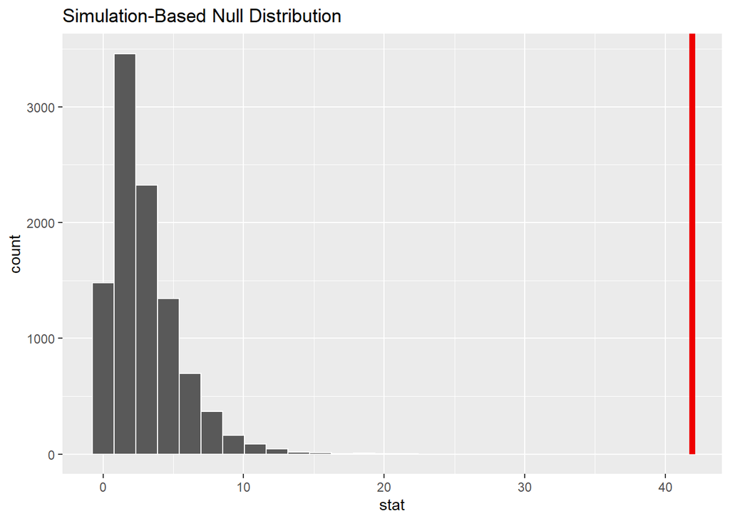

```r
set.seed(13)
# Calculate Chi-square Independence test using infer
chi_sq2 <- datA %>%
  specify(response = sex, explanatory = rank, success = "Male") %>%
  hypothesize(null = "independence") %>%
  calculate(stat = "Chisq")

# Generate Null Distribution
null_dist_2 <- datA %>%
  specify(response = sex, explanatory = rank, success = "Male") %>%
  hypothesize(null = "independence") %>%
  generate(reps = 10000, type = "permute") %>%
  calculate(stat = "Chisq")

# Visualize where calculated chi-square falls on distribution
null_dist_2 %>%
  visualize() +
  shade_p_value(chi_sq2, direction = "greater")
```

```r
null_dist_2 %>%
  get_p_value(obs_stat = chi_sq2$stat, direction="greater")
```

```
## # A tibble: 1 × 1
##   p_value
##     <dbl>
## 1       0
```

```r
# OR

pchisq(chi_sq2$stat, 3, lower.tail = FALSE)
```

```
##    X-squared
## 4.228693e-09
```

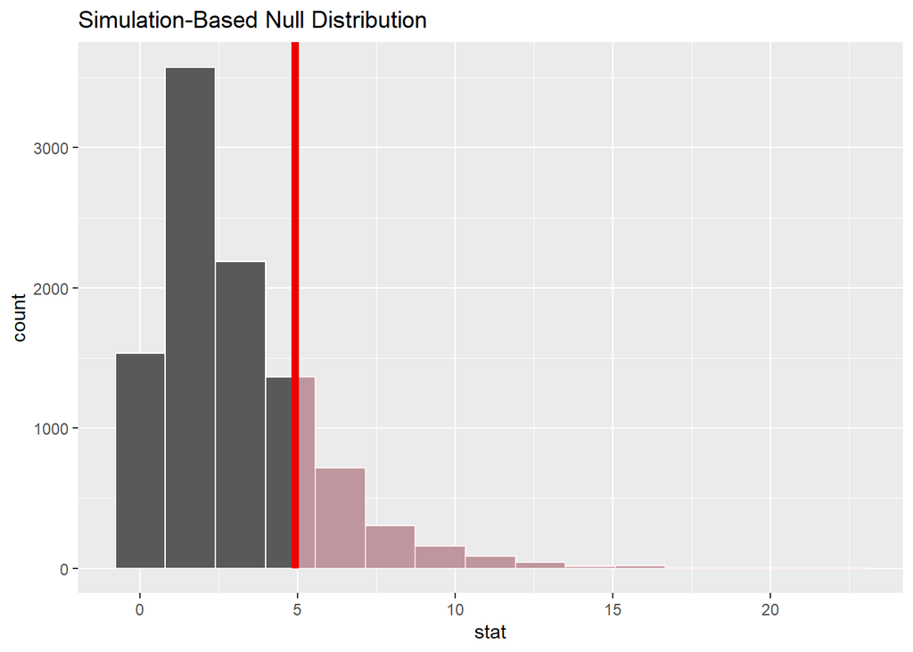

```r
set.seed(13)
# Calculate Chi-square independence test using infer
chi_sq3 <- datA %>%
  specify(response = level, explanatory = rank, success = "Doctorate") %>%
  hypothesize(null = "independence") %>%
  calculate(stat = "Chisq")

# Generate Null Distribution
null_dist_3 <- datA %>%
  specify(response = level, explanatory = rank, success = "Doctorate") %>%
  hypothesize(null = "independence") %>%
  generate(reps = 10000, type = "permute") %>%
  calculate(stat = "Chisq")

# Visualize where calculated chi-square falls on distribution
null_dist_3 %>%
  visualize() +
  shade_p_value(chi_sq3,
                direction = "greater")
```

```r
null_dist_3 %>%
  get_p_value(obs_stat = chi_sq3$stat, direction="greater")
```

```
## # A tibble: 1 × 1
##   p_value
##     <dbl>
## 1   0.176
```

```r
# OR

pchisq(chi_sq3$stat, 3, lower.tail = FALSE)
```

```
## X-squared
## 0.1787723
```

**The main difference between the `bootstrap` and `permute` functions in the infer pipeline**:

- `bootstrapping` — best for estimating confidence intervals
- `permuting` — best for testing hypotheses